RELATIONAL ADVANTAGE · DIFFUSION

# The Ties That Open a Community Are Not the Ties That Move It

Task-Specific Relational Advantage in Diffusion

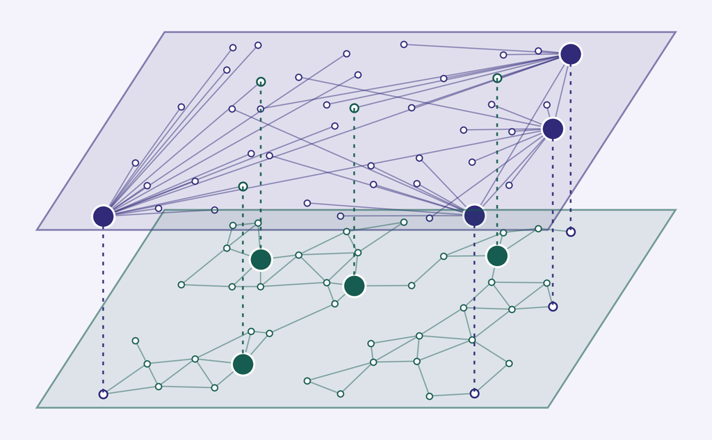

Roberto Cantillan & Mauricio Bucca

Department of Sociology · Pontificia Universidad Católica de Chile

## Who opens a community—and who moves it?

The question

### Entry

An organization approaches the people others **consult**.

### Adoption

Households decide whether to **commit** to a costly practice.

Does the relational advantage that helps at entry carry into adoption?

Katz & Lazarsfeld 1955 · Banerjee et al. 2013, 2019 · Beaman et al. 2021

## An opening matters through what follows

Diffusion as a sequence of accomplishments

An event acquires consequences through its connections to subsequent action.

### Entry

An opportunity arrives.

### Information

People become aware.

### Adoption

People decide to commit.

What connects one accomplishment to the next need not be the same relation.

Conceptual adaptation of Rule, Sabetta & Bearman (2026), “Pathways and Chance,” Sociologica, §4.

## A change of task can change which ties matter

The argument

### The household others consult

Visible prominence makes it a plausible point of **organizational entry**.

### The household others visit

Routine contact may support **observation, reassurance, and coordination**.

Advantage comes from the match between a position and a task.

Illustrative households; the capacities are proposed mechanisms, not measured tie content.

## Portability is continuity of relational advantage

The concept

An advantage is **portable** when the position that helps an actor at one task remains advantageous at the next.

A **relation** is a domain of ties, such as advice or visiting.

A **task** is an accomplishment needed for the process to advance, such as reaching people or eliciting adoption.

We compare successive tasks within a process, with the actors’ positions held fixed.

## We explain when relational advantage carries forward

The conceptual contribution

Relational position supplies access to **capacities**: communication, judgment, material support, observation, or coordination.

A task makes some of those capacities more consequential. **Advantage arises from the match between position and task.**

As the process advances, a new match can reorder the same actors—even while their networks remain fixed.

Portability becomes an outcome to explain through capacities, task demands, and relative positions.

## Advantage is a match between position and task

A minimal formalization

$$R_{ir}=\sum_l \omega_{lr}\,x_{il}$$

**Position** $x_{il}$: where actor $i$ stands in relational domain $l$.

**Match** $\omega_{lr}$: how well the domain’s capacities fit task $r$.

**Advantage** $R_{ir}$: the actor’s resulting task-specific score.

Positions can stay fixed while the task changes what they are worth.

## Nonportability requires three conditions

Theory

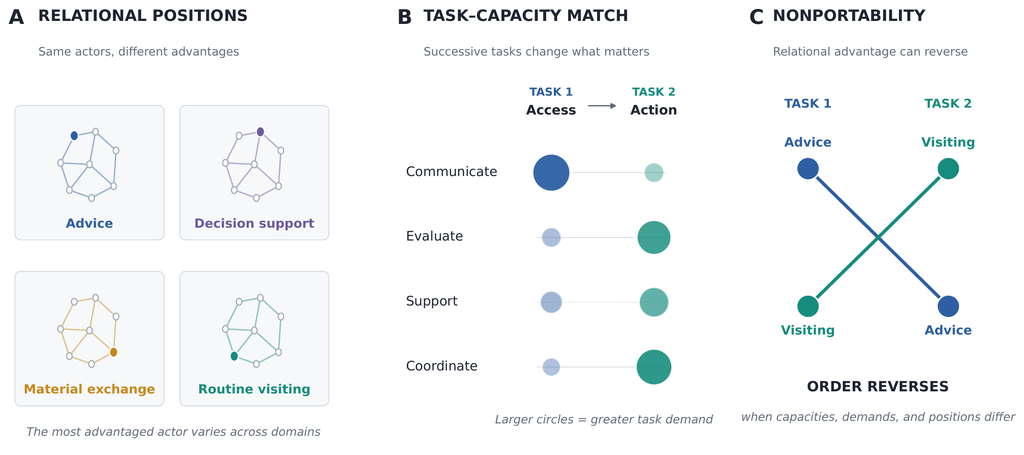

Task–capacity matching: positions across domains, task demands, and possible reordering.

Different capacities × different demands × different positions.

## The three conditions work jointly

Why a score can change

$$R_{i2}-R_{i1}=\frac{s}{2}(\tau_2-\tau_1)(x_{i1}-x_{i2})$$

**Different capacities:** $s$ measures domain specialization.

**Different demands:** $\tau_2-\tau_1$ measures the task shift.

**Different positions:** $x_{i1}-x_{i2}$ is the actor’s relational profile.

If any factor is zero, the actor’s score does not change.

## Positions can differ; advantage can reverse

Derived implications · Conditions and core test

H1 · A necessary structural condition

### Domains rank the same actors differently.

If positions coincide, changing task weights cannot reorder actors.

H2 · The substantive prediction in this setting

### Entry favors Advice/Decision; adoption favors Visiting.

If task demands shift toward capacities supported by visiting, the domain associated with advantage should reverse.

H1 makes reordering possible. H2 tests the predicted change of domain; it does not identify the capacities themselves.

## Pooling can hide a task-specific advantage

Derived implication · H3

Domain-specific position preserves differences between relational infrastructures.

Union-network position pools ties before asking what the task requires.

**H3:** if adoption-relevant advantage lies in Visiting, pooling other domains can dilute its signal.

The value of aggregation depends on the task and on how actors’ positions correspond.

## Two datasets address different tasks

Empirical design

**BSS · Household entry and adoption**  
Pre-program networks in 75 villages; joint outcome comparisons for 10,618 households in 49 villages.

**Randomized seeding · Information reach**  
An independent experiment in 68 villages: randomly selected seeds share news; missed calls record receipt.

BSS provides the within-setting contrast. The experiment benchmarks the information task.

## Networks precede the arrival of microcredit

Setting · Karnataka, India

10,618

Households in the adoption analysis

49 / 75

Adoption villages / network villages

17.3%

Households that took up a BSS loan

- Networks measured in **2006**, about six months before entry.
- BSS designated **12%** of households using locally influential roles.
- The lender **did not observe the networks** when choosing entry points.

Banerjee, Chandrasekhar, Duflo & Jackson 2013

## Nominations become comparable household networks

Network construction · BSS

**Nodes:** households on a common village roster.

**Ties:** combine each pair of name generators. A nomination in either direction creates one binary, undirected tie; self-ties are removed.

**Positions:** compute diffusion centrality separately in each domain, then scale it to $[0,1]$ within village and domain.

The same households and position measure allow comparisons across relations.

## Three focal domains capture contrasting capacities

Measurement · The main comparison

| Domain | Reported ties | Plausible capacities |
| --- | --- | --- |
| **Advice/Decision** | Advice and decision support | Communication · judgment |
| **Exchange** | Money lending and borrowing | Material support · risk buffering |
| **Visiting** | Visits to each other’s homes | Observation · coordination |

These are the focal domains. The SI also examines every remaining BSS relation.

Paired name generators; undirected layers. Capacities are proposed, not directly observed.

## Random seeding isolates the information benchmark

Dataset 2 · Design and network measurement

Three or five households per village are randomly chosen to receive and share news. Other households register receipt with a missed call.

The survey distinguishes **Advice, Decision Support, Visiting, and Material Exchange**.

Seed-set positions are compared with their within-village randomization distribution; the outcome is **calls per household**.

Domains are harmonized across datasets; the units and outcomes remain distinct.

## The studies answer different parts of the argument

Evidence · Keep the units distinct

| Dataset and unit | Observed outcome | Role in the argument |
| --- | --- | --- |
| **BSS · Households** | Designation as entry point | Organizational selection |
| **BSS · Same households** | Own loan adoption | Within-setting task comparison |
| **RCT · Village seed sets** | Realized informational reach | Independent information benchmark |

BSS identifies the within-setting contrast. The RCT supplies an independent information benchmark.

Different villages, units, and outcomes: these coefficients are not pooled or subtracted.

## Entry and adoption use identical comparisons

Design · Primary evidence

### Entry designation

Was the household in the lender’s **designated entry pool**?

### Own adoption

Did the household **take up a BSS loan**?

- The three domain positions enter **together** in each model.
- Compare households **within village**, with identical controls.
- Estimate the two equations jointly; cluster uncertainty by village.

Controls: union degree, wealth, and network-survey participation. Linear probability models.

## Entry tracks advice; adoption tracks visiting

The answer in Karnataka

### Advice / Decision

The households the lender designated as **entry points**.

### Visiting

The households that **took up a loan** themselves.

Same households. Same villages. Different relational advantages.

Primary comparison: 10,618 households in 49 villages. Observational associations.

## H1 · Households rank differently across domains

Results · Positional differentiation

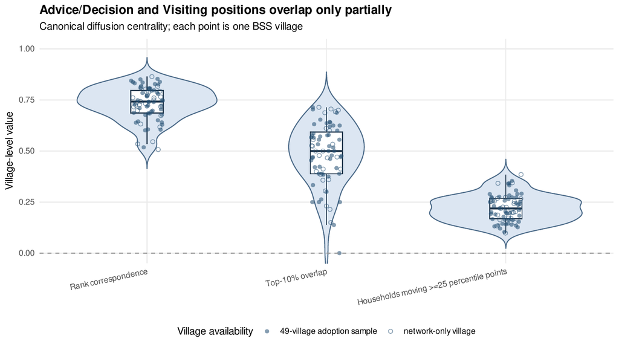

Cross-domain positional differentiation in the 75 Karnataka villages.

.742

Median rank correlation

50%

Top-decile overlap in the median village

21.8%

Move at least 25 percentile points

75 villages · Advice/Decision versus Visiting · Correlation IQR: .686–.796

## H2 · Entry and adoption favor different domains

Results · Same households, two outcomes

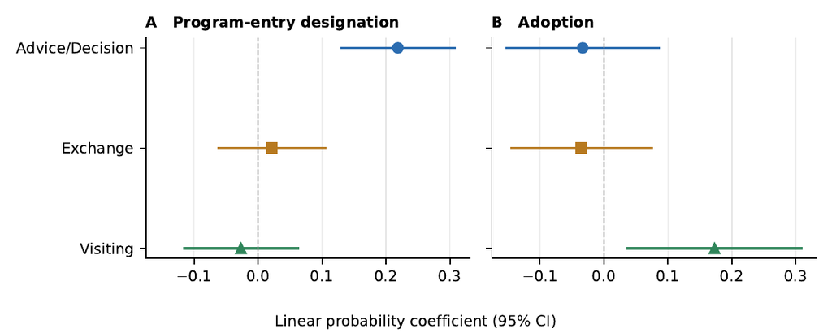

Coefficients for entry designation and adoption, with 95% confidence intervals.

**Entry:** Advice/Decision $b=0.219$, $p<.001$

**Adoption:** Visiting $b=0.173$, $p=.012$

10,618 households · 49 villages · All three domains in each model · Village-clustered 95% CIs

## The reversal is a tested contrast

Results · Beyond a difference in significance

### Visiting minus Advice/Decision

**At entry:** $-0.246$  
**At adoption:** $+0.206$

Θ = 0.451

Change in the domain contrast  
SE $0.103$ · $p<.001$

Moving from the 25th to the 75th percentile of Visiting position corresponds to **4.3 pp** more adoption.

Adoption base rate: 17.3%. Rounded domain gaps may differ slightly from the unrounded joint contrast.

## The Visiting association survives key checks

Results · Robustness

| Check | Result |
| --- | --- |
| **Leave one village out** | Visiting stays positive and significant in all **49** estimates. |
| **Exclude the entry pool** | Visiting $b=0.168$, $p=.025$. |
| **Small-cluster inference** | Visiting wild-cluster bootstrap $p=.021$. |
| **Alternative measurement** | All **8** reversal contrasts and all **16** adoption domain contrasts are positive. |

Seven of eight reversal tests have p < .05; 15 of 16 adoption contrast intervals exclude zero.

## Visiting survives the inclusion of other relations

Measurement · The broader BSS audit

### Relations examined in the SI

Medical consultation · temple co-presence · kinship · nonkin nominations · rice/kerosene exchange

0.148–0.179

Visiting coefficient after adding these relations  
All $p<.05$

Rice/kerosene inflow also predicts adoption: $b=0.107$, $p=.048$.

Supplementary table: “Adoption models adding the remaining BSS relations.” Added relations enter in separate specifications.

## H3 · Pooling ties conceals the adoption signal

Results · Same sample and specification

### Union centrality

−0.025

Association with adoption  
SE $0.070$ · $p=.72$

### Visiting centrality

+0.156

Association with adoption  
$p=.030$

Visiting exceeds the union coefficient by **0.181** (SE $0.058$, $p=.003$).

Contrast between two single-measure models estimated jointly. Within-village household adoption.

## The Visiting signal is concentrated in nearby ties

Results · Main qualification

### Nearby Visiting ties

+0.080

$p=.017$

### Other Visiting ties

+0.019

$p=.71$

Learning from neighbors and neighborhood differences in exposure remain competing explanations.

Near = within five positions in census enumeration order; 32.9% of Visiting ties. Location proxy, not coordinates.

## Advice favors information reach in the RCT

Independent benchmark · Randomized seeding

### 68 villages

**3 or 5 seeds**, randomly assigned within each village.

Other households record receipt with a **missed call**.

−0.684 SD

Visiting minus Advice  
Calls per household  
Randomization $p=.030$

Advice seed positions yield more informational reach; precision varies with scaling and outcome.

Chandrasekhar et al. 2026 · Original scaling: −0.717, conventional p = .09. Unique calls: randomization p = .072.

## A changed score need not reorder actors

Decomposing the phenomenon · Individual level

$$R_{ir}=m_i+s\tau_r d_i$$

**Common standing** $m_i=(x_{i1}+x_{i2})/2$: the actor’s mean position.

**Relative profile** $d_i=(x_{i1}-x_{i2})/2$: which domain favors the actor.

A task shift changes the weight on the profile. A pair reverses only when that change overcomes its gap in common standing.

Score change → possible rank reversal; the pair’s threshold determines whether it occurs.

## Reordering and collective loss are distinct outcomes

Measuring portability · Three outcomes

**1 · All actors:** how many pairs exchange places between tasks? → Panel A.

**2 · Sequential passage:** does reordering persist when pairs are weighted by both actors’ probabilities of passing task 1? → Panel B.

**3 · Reuse:** how much task-2 coverage is lost by retaining the task-1 initiator set? → Panel C.

Redundant reach can absorb individual reordering and keep collective loss small.

## The model changes task weights over fixed layers

Model · Task-specific reach

$$A_r=\omega_{1r}A_1+\omega_{2r}A_2$$

Task weights combine the two infrastructures; bounded walks imply reach probabilities.

For each task, select **five initiators** to maximize coverage while accounting for overlapping reach.

Vary specialization, task demands, and cross-layer correspondence independently: **100 pairs of 80-actor networks per condition**.

Reevaluate the task-1 set under task 2, then compare it with the task-2 selection.

## Task change can reorder actors

Model · Panel A

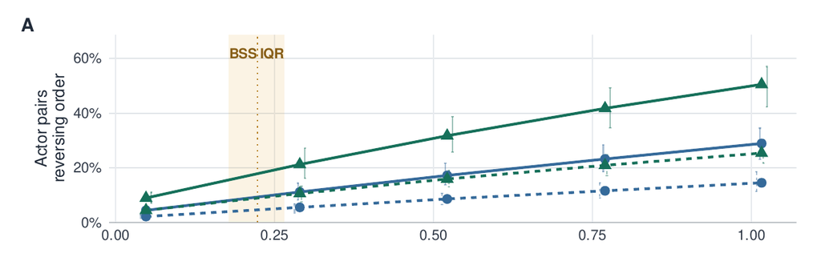

With full differentiation and complete task change: **9.0% → 50.5%** of actor pairs reverse.

Horizontal axis: 1 − cross-layer rank correlation. Green: full differentiation; blue: intermediate. Solid: complete task shift; dashed: partial. Band: BSS IQR.

## Reordering persists among actors reached at task 1

Model · Panel B

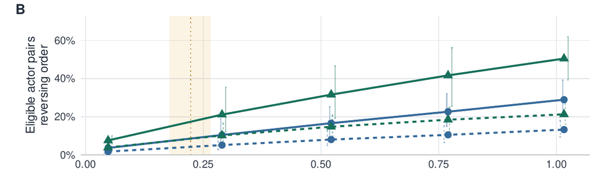

Weight each pair by both actors’ probability of passing task 1. **The same broad pattern remains.**

Horizontal axis: 1 − cross-layer rank correlation. Green: full differentiation; blue: intermediate. Solid: complete task shift; dashed: partial. Band: BSS IQR.

## Extensive reordering makes reuse costly

Model · Panel C

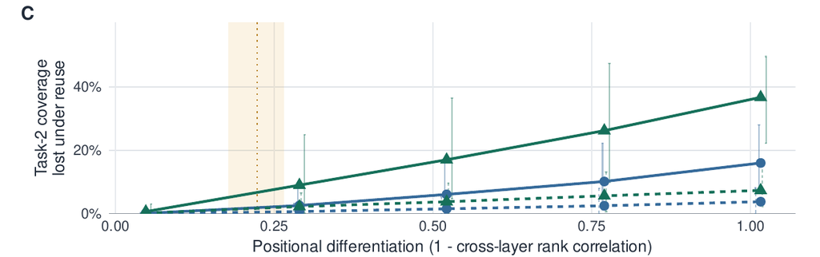

With full differentiation and complete task change: **0.7% → 36.7%** of attainable task-2 coverage is lost.

Horizontal axis: 1 − cross-layer rank correlation. Green: full differentiation; blue: intermediate. Solid: complete task shift; dashed: partial. Band: BSS IQR.

## Karnataka has high cross-domain correspondence

Model · Locate the empirical setting

.776

Median cross-domain correspondence

9.5% / 18.8%

Pairs reversing  
Partial / complete task shift

1.6% / 6.8%

Modeled reuse loss  
Partial / complete task shift

At this correspondence, redundant reach absorbs much of the reordering.

Synthetic-model implications at BSS median correspondence, with complete differentiation. Model reach metric; IQR .734–.822.

## What the evidence establishes—and leaves open

Interpretation

### Established pattern

Entry and own adoption associate with **different relational domains**.

The aggregate network conceals that contrast.

### Open explanation

Tie capacities are **not directly measured**.

Nearby exposure and homophily remain possible; the cross-village moderation test is uninformative.

The result concerns household positions. It does not identify who caused others to adopt.

## Portability links relational structure to process

Conceptual contribution · What the evidence supports

The relevant question is whether **an advantage survives the next task**, and under what conditions.

Capacity–demand matching explains how a fixed relational position can acquire a different value as the process advances.

Relative profiles explain who can exchange places. Collective reach explains whether those changes matter for an intervention.

A portable strategy requires continuity of useful reach across tasks, not just prominent initiators.

## Central in which relation—and for which task?

Discussion

The ties that open an opportunity  
need not organize the decision to act.

**Entry → Advice/Decision**

**Adoption → Visiting**

Roberto Cantillan · Mauricio Bucca  
Pontificia Universidad Católica de Chile

# Appendix

## A1 · The contribution connects structural and multiplex work

STRUCTURAL WORK

#### The returns to targeting depend on how ties are organized

Complex contagion, network paradoxes, multiplex seeding.

Centola & Macy 2007; Hsiao & Christakis 2026; Chandrasekhar et al. 2026

MULTIPLEX WORK

#### Relations are not interchangeable channels

Pooling them can hide the one that matters for an outcome.

Omodei & Arenas 2016; Becker et al. 2020; Larson & Rodríguez 2023

Both show that **different relations matter**. Neither asks whether an advantage established for one task **survives a change of task**.

## A2 · Diffusion centrality

$$\mathrm{DC}(i)=\left[\sum_{t=0}^{T}(qA)^t\mathbf{1}\right]_i$$

- **$A$:** adjacency matrix of one relational domain.
- **$q=1/\lambda_{\max}(A)$; $T$:** layer diameter.
- Counts expected transmissions through walks of bounded length; repeated arrivals can count more than once.
- Normalize to **$[0,1]$ within village and domain** before estimation.

## A3 · Joint outcome models and the reversal contrast

$$Y_{iv}^{k}=\alpha_v^k+\sum_{l\in\{AD,E,V\}}\beta_l^k\,\mathrm{DC}_{liv}+\mathbf{X}_{iv}'\gamma^k+\varepsilon_{iv}^k$$

$$\Theta=(\beta_V^U-\beta_{AD}^U)-(\beta_V^G-\beta_{AD}^G)$$

- **$G$:** designation; **$U$:** own uptake. Same sample and controls.
- **$\alpha_v^k$:** village fixed effects. Controls: union degree, wealth, survey participation.
- Joint estimation retains covariance across outcomes; uncertainty clustered by village.

## A4 · When do two actors exchange places?

$$\left(\Delta m_{ij}+s\tau_1\Delta d_{ij}\right)\left(\Delta m_{ij}+s\tau_2\Delta d_{ij}\right)<0$$

- **Common position:** $m_i=(x_{i1}+x_{i2})/2$.
- **Relational profile:** $d_i=(x_{i1}-x_{i2})/2$.
- $\Delta m_{ij}$ and $\Delta d_{ij}$ compare actors $i$ and $j$.
- A negative product means **opposite orderings** at the two tasks.

Different task scores do not necessarily imply different rankings.

## A5 · Checks on rival explanations

| Threat | What could produce the pattern | What we do |
| --- | --- | --- |
| **General prominence** | Visiting just marks wealthier or more active households | Control union degree and wealth; compare opposite relational profiles after balancing on prominence; drop the entry pool |
| **Composition, homophily** | Caste structures both relations and access to credit | Sub-caste fixed effects; residualize on caste, religion, housing; estimate by caste |
| **Spatial proximity** | Visiting is local; nearby households may share exposure | Census enumeration order as a proxy; split Visiting ties into near and far |
| **Measurement** | Sampled respondents; composites; the pool is not the households contacted | Each constituent name generator; four scales; four sample restrictions |

A generic prominence account predicts the same positions have similar associations across tasks, not that different domains order them for different tasks.

## A6 · Composition and the secondary test

SPATIAL PROXIMITY

The adoption association is carried by ties between **nearby households** ($b=0.080$, $p=.017$); other Visiting ties do not ($b=0.019$, $p=.71$).

Reading Learning from neighbors **or** neighborhood differences in exposure: the data cannot separate the two.

WHO DRIVES IT

Concentrated among **lower-caste households** (interaction $b=0.159$, $p=.008$).

Balancing on prominence Visiting-oriented households adopt 2.4 pp more, interval $[-1.2, 5.9]$: consistent with, not independent confirmation of, the main result.

SECONDARY TEST: UNINFORMATIVE

Entry-pool advantage should shrink where domains diverge. The interaction is indistinguishable from zero ($b=-0.008$, $p=.96$), and cross-village variation is narrow (SD of $1-\rho_v$ is 0.08). **Neither support nor refutation.**

## A7 · Decision support versus advice: exploratory

- Separating the generators behind Advice/Decision: **Decision Support** centrality is negatively associated with adoption (standardized $b=-0.059$, $p=.003$).
- The *relative* profile matters: Decision Support minus Advice predicts lower adoption ($b=-0.099$, $p=.005$); their sum does not ($b=-0.020$, $p=.48$).
- Sharpest among entry-pool households (interaction $b=-0.074$, $p<.001$).
- The reversal is larger when Advice/Decision is represented by the decision generator (0.495 to 0.538) than by the advice generator (0.192 to 0.287).

Deliberative prominence as such does not predict lower adoption; ranking higher as a source of decision support than of advice does. **Outside H1–H3 and exploratory.**

## A8 · Simulation design and sensitivity

$$A_r=\omega_{1r}A_1+\omega_{2r}A_2$$

| Component | Design |
| --- | --- |
| **Three conditions** | Differentiation: 0, .5, 1; task shift: none, partial, complete; correspondence varied by relabeling. |
| **Network realizations** | 100 pairs per condition; 80 actors; group structure and heterogeneous activity. |
| **Selection** | Five initiators per task, chosen to maximize overlapping reach. |
| **Validation** | Three null cases return zero. Smaller networks checked by exhaustive enumeration. |

Sensitivity: reach horizon, attenuation, exposure scale, budget, degree, group structure. Extreme-case reuse loss: .262–.545.

## A9 · The full simulation figure

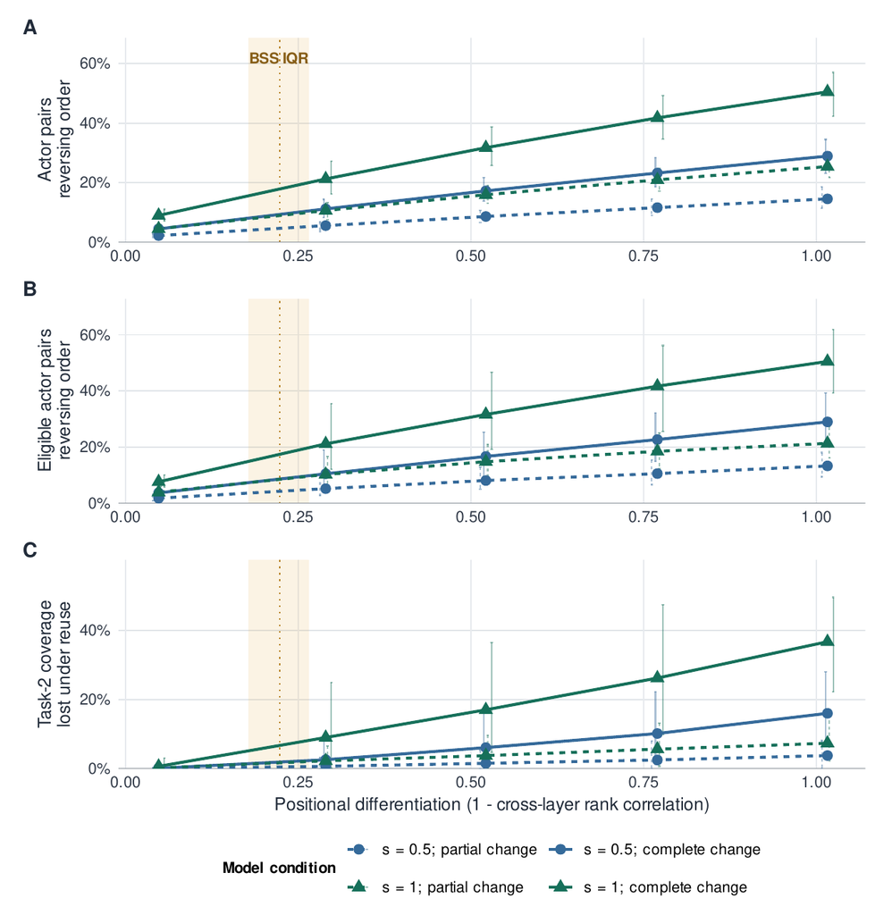

All three simulation outcomes: pair reversals, eligibility-weighted reversals, and reuse loss.

Green: s = 1; blue: s = .5. Solid: complete task shift; dashed: partial. Band: BSS correspondence IQR.

## A10 · Observed-network losses are ceilings

### 21.4%

Household pairs reversing

### 15.0%

Modeled reuse loss  
6.6% at the lower end of the bootstrap range

- Treats outcome associations as **task–capacity weights**: an unvalidated assumption.
- Entry loads entirely on Advice/Decision; adoption entirely on Visiting.
- These are **ceilings**, not estimates of what BSS actually gained or lost.

Observed layers in 49 adoption villages; five initiators. Synthetic and observed-network figures are not comparable estimates.

## A11 · Additional relations in the adoption models

Supplementary evidence

| Added relation | Added $b$ | $p$ | Visiting $b$ |
| --- | --- | --- | --- |
| Medical consultation | .004 | .898 | .173 |
| Temple co-presence | .030 | .285 | .175 |
| Temple + nonkin (nonkin term) | −.016 | .655 | .179 |
| Kinship | .058 | .097 | .169 |
| Rice/kerosene inflow | .107 | .048 | .148 |
| Rice/kerosene outflow | −.029 | .614 | .148 |

Every Visiting coefficient has p < .05. Inflow and outflow enter together; the other rows refer to separate specifications.

## Selected references · 1

- **Banerjee, A., Chandrasekhar, A. G., Duflo, E., & Jackson, M. O. (2013).** “The Diffusion of Microfinance.” *Science* 341(6144). doi:10.1126/science.1236498.
- **Banerjee, A., Chandrasekhar, A. G., Duflo, E., & Jackson, M. O. (2019).** “Using Gossips to Spread Information: Theory and Evidence from Two Randomized Controlled Trials.” *The Review of Economic Studies* 86(6):2453–2490. doi:10.1093/restud/rdz008.
- **Beaman, L., BenYishay, A., Magruder, J., & Mobarak, A. M. (2021).** “Can Network Theory-Based Targeting Increase Technology Adoption?” *American Economic Review* 111(6):1918–1943. doi:10.1257/aer.20200295.
- **Becker, S. O., Hsiao, Y., Pfaff, S., & Rubin, J. (2020).** “Multiplex Network Ties and the Spatial Diffusion of Radical Innovations: Martin Luther’s Leadership in the Early Reformation.” *American Sociological Review* 85(5):857–894. doi:10.1177/0003122420948059.

## Selected references · 2

- **Centola, D. & Macy, M. (2007).** “Complex Contagions and the Weakness of Long Ties.” *American Journal of Sociology* 113(3):702–734. doi:10.1086/521848.
- **Chandrasekhar, A. G., Chaudhary, V., Golub, B., & Jackson, M. O. (2026).** “Multiplexing in Networks and Diffusion.” *Proceedings of the National Academy of Sciences* 123(28). doi:10.1073/pnas.2534923123.
- **Hsiao, Y. & Christakis, N. A. (2026).** “The Influence “Paradox”: When More Network Ties Lead to Less Change.” *American Sociological Review* 91(3):464–489. doi:10.1177/00031224261438845.
- **Larson, J. M. & Rodríguez, P. L. (2023).** “The Risk of Aggregating Networks When Diffusion Is Tie-Specific.” *Applied Network Science* 8:21. doi:10.1007/s41109-023-00546-7.

## Selected references · 3

- **Omodei, E. & Arenas, A. (2016).** “Untangling the Role of Diverse Social Dimensions in the Diffusion of Microfinance.” *Applied Network Science* 1(1):14. doi:10.1007/s41109-016-0016-x.
- **Rule, A., Sabetta, L., & Bearman, P. (2026).** “Pathways and Chance.” *Sociologica* 20(1). doi:10.60923/issn.1971-8853/23641.
- **Valente, T. W. & Davis, R. L. (1999).** “Accelerating the Diffusion of Innovations Using Opinion Leaders.” *The ANNALS of the American Academy of Political and Social Science* 566(1):55–67. doi:10.1177/000271629956600105.